# Bortkewitsch’s Horsekicks

coop711

2015년 5월 18일

프러시아에서 20년간 14개 연대에서 발생한 말발굽에 채여 사망한 사고 기록 [^1] [^1]: 원시자료는 `pscl` 패키지의 `prussian`이다.

```
## 'data.frame':    280 obs. of  3 variables:
##  $ y   : int  0 2 2 1 0 0 1 1 0 3 ...
##  $ year: int  75 76 77 78 79 80 81 82 83 84 ...
##  $ corp: Factor w/ 14 levels "G","I","II","III",..: 1 1 1 1 1 1 1 1 1 1 ...
```

| 0 | 1 | 2 | 3 | 4 |
| --- | --- | --- | --- | --- |
| 144 | 91 | 32 | 11 | 2 |

```r
n_deaths <- 0:4
n_corps <- c(144, 91, 32, 11, 2)
horsekick <- data.frame(Deaths = n_deaths, Corps = n_corps)
pander(t(horsekick))
```

| **Deaths** | 0 | 1 | 2 | 3 | 4 |
| --- | --- | --- | --- | --- | --- |
| **Corps** | 144 | 91 | 32 | 11 | 2 |

이 자료를 하나의 긴 벡터로 나타내는 것은 간단히

```r
horsekick_long <- rep(n_deaths, n_corps)
str(horsekick_long)
```

```
##  int [1:280] 0 0 0 0 0 0 0 0 0 0 ...
```

```r
summary(horsekick_long)
```

```
##    Min. 1st Qu.  Median    Mean 3rd Qu.    Max.
##     0.0     0.0     0.0     0.7     1.0     4.0
```

위 자료를 누적분포로 도식화하기 위한 첫 작업

```r
options(digits = 3)
```

```
#> 한글 폰트 설정
```

```r
par(family = "HCR Dotum LVT")
```

```
#> 백분율로 표시
```

```r
horsekick_p <- n_corps / sum(n_corps)
```

```
#> 누적백분율
```

```r
horsekick_cum <- round(cumsum(horsekick_p) * 100, digits = 1)
```

```
#> 백분율과 누적백분율 비교
```

```r
cbind(horsekick_p, horsekick_cum)
```

```
##      horsekick_p horsekick_cum
## [1,]     0.51429          51.4
## [2,]     0.32500          83.9
## [3,]     0.11429          95.4
## [4,]     0.03929          99.3
## [5,]     0.00714         100.0
```

```
#> 누적백분율을 점으로 표시. `yaxt = "n"` 의 효과 확인
```

```r
plot(x = n_deaths, y = horsekick_cum,
     xlim = c(-0.5, 4.5), ylim = c(50, 100),
     xlab = "사망자 수", ylab = "누적 백분률(%)",
     yaxt = "n")
```

```
#> `axis()` 함수를 이용하여 `y`축 설정. `las = 2`의 역할에 유의
```

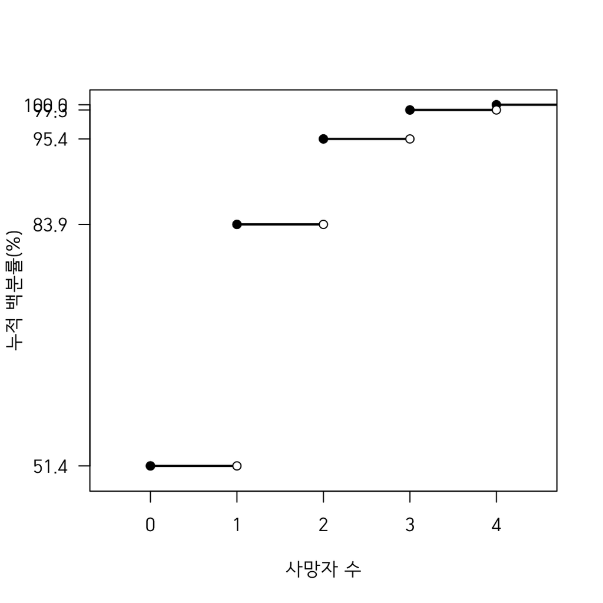

```r
axis(side = 2,
     at = horsekick_cum,
     labels = format(horsekick_cum, nsmall = 1),
     las = 2)
lines(x = c(0, 1), y = rep(horsekick_cum[1], 2), lty = 1, lwd = 2)
lines(x = c(1, 2), y = rep(horsekick_cum[2], 2), lty = 1, lwd = 2)
lines(x = c(2, 3), y = rep(horsekick_cum[3], 2), lty = 1, lwd = 2)
lines(x = c(3, 4), y = rep(horsekick_cum[4], 2), lty = 1, lwd = 2)
lines(x = c(4, 5), y = rep(horsekick_cum[5], 2), lty = 1, lwd = 2)
points(x = n_deaths, y = horsekick_cum,
       pch = 21, bg = "black", col = "black")
points(x = n_deaths[2:5], y = horsekick_cum[1:4],
       pch = 21, bg = "white", col = "black")
```

누적 분포를 알기 쉽도록 격자 설정. 구분선을 아래서부터 차례로 그려갈 때

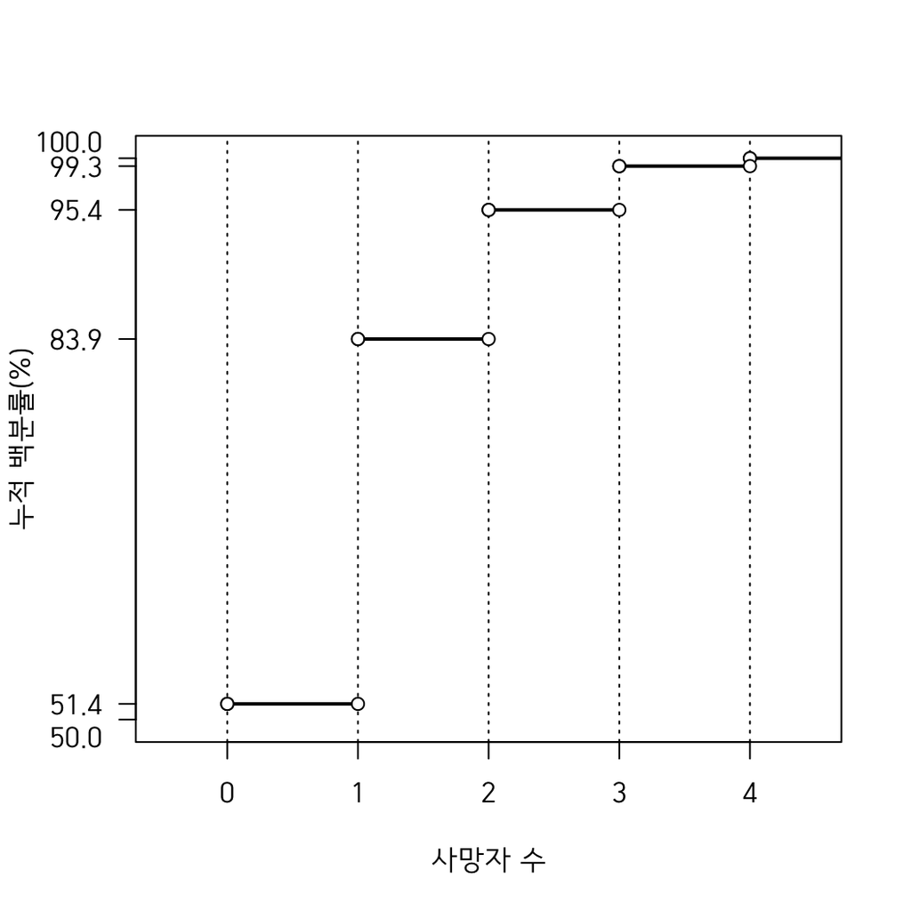

```r
options(digits = 3)
par(family = "HCR Dotum LVT")
plot(x = n_deaths, y = horsekick_cum,
     xlim = c(-0.5,4.5), ylim = c(50, 100),
     xlab = "사망자 수", ylab = "누적 백분률(%)",
     yaxt = "n")
axis(side = 2,
     at = c(50, horsekick_cum),
     labels = format(c("", horsekick_cum[1:4], ""), nsmall = 1),
     las = 2)
axis(side = 2,
     at = c(48.5, horsekick_cum[5] + 1.5),
     tick = FALSE,
     labels = format(c(50, horsekick_cum[5]), nsmall = 1),
     las = 2)
abline(v = 0:4,
       lty = 3)
lines(c(0, 1), rep(horsekick_cum[1], 2), lty = 1, lwd = 2)
lines(c(1, 2), rep(horsekick_cum[2], 2), lty = 1, lwd = 2)
lines(c(2, 3), rep(horsekick_cum[3], 2), lty = 1, lwd = 2)
lines(c(3, 4), rep(horsekick_cum[4], 2), lty = 1, lwd = 2)
lines(c(4, 5), rep(horsekick_cum[5], 2), lty = 1, lwd = 2)
points(x = n_deaths, y = horsekick_cum,
       pch = 21, bg = "white", col = "black")
points(x = n_deaths[2:5], y = horsekick_cum[1:4],
       pch = 21, bg = "white", col = "black")
```

반복되는 `lines()`는 아래와 같이 `apply()`를 이용하여 작업을 다소 줄일 수도 있다. 우선, 좌표를 정리한다.

```r
h_x <- cbind(rep(0, 5), 1:5)
h_x
```

```
##      [,1] [,2]
## [1,]    0    1
## [2,]    0    2
## [3,]    0    3
## [4,]    0    4
## [5,]    0    5
```

```r
h_y <- sapply(horsekick_cum, rep, 2)
h_y
```

```
##      [,1] [,2] [,3] [,4] [,5]
## [1,] 51.4 83.9 95.4 99.3  100
## [2,] 51.4 83.9 95.4 99.3  100
```

```r
h_xy <- cbind(h_x, t(h_y))
h_xy
```

```
##      [,1] [,2]  [,3]  [,4]
## [1,]    0    1  51.4  51.4
## [2,]    0    2  83.9  83.9
## [3,]    0    3  95.4  95.4
## [4,]    0    4  99.3  99.3
## [5,]    0    5 100.0 100.0
```

`plot()`에서 `abline()`까지가 반복해서 나올 것이므로, `source()`를 이용하기 위한 코드 작성.

격자선을 놓는 과정까지를 두 줄로 줄일 수 있다.

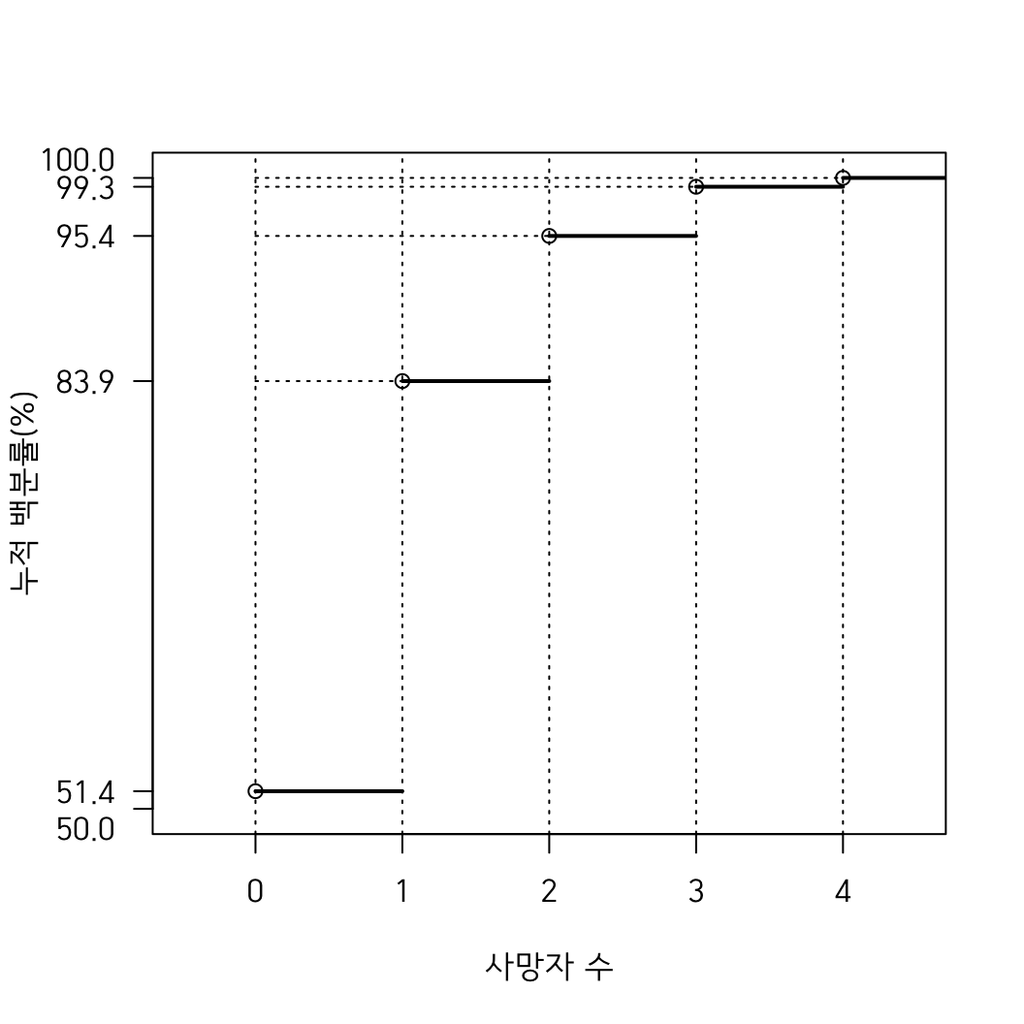

```r
par(family = "HCR Dotum LVT")
source("./horsekick_plot.R", echo = FALSE)
apply(h_xy, MARGIN = 1,
      FUN = function(h) lines(x = h[1:2], y = h[3:4], lty = 3))
```

```r
l_xy <- function(h) lines(x = h[1:2], y = h[3:4], lty = 3)
```

누적분포 윗 면적을 명확히 표시하기 위하여 빗금

```r
png(filename = "../pics/horsekick_cum.png", width = 480, height = 480)
par(family = "HCR Dotum LVT")
library(RColorBrewer)
h_pal <- brewer.pal(4, name = "Purples")
source("horsekick_plot.R", echo = FALSE)
apply(h_xy, MARGIN = 1, FUN = l_xy)
```

```r
polygon(c(0, 1, 1, 0), c(rep(horsekick_cum[1], 2), rep(horsekick_cum[5], 2)),
        col = h_pal[1])
polygon(c(1, 2, 2, 1), c(rep(horsekick_cum[2], 2), rep(horsekick_cum[5], 2)),
        col = h_pal[2])
polygon(c(2, 3, 3, 2), c(rep(horsekick_cum[3], 2), rep(horsekick_cum[5], 2)),
        col = h_pal[3])
polygon(c(3, 4, 4, 3), c(rep(horsekick_cum[4], 2), rep(horsekick_cum[5], 2)),
        col = h_pal[4])
points(x = n_deaths, y = horsekick_cum,
       pch = 21, bg = "black", col = "black")
points(x = n_deaths[2:5], y = horsekick_cum[1:4],
       pch = 21, bg = "white", col = "black")
dev.off()
```

`polygon()`들을 한 줄로 정리하기 위하여 좌표들을 모으고,

```r
poly_x <- matrix(c(0:3, rep(1:4, 2), 0:3), ncol = 4, byrow = T)
poly_x
```

```
##      [,1] [,2] [,3] [,4]
## [1,]    0    1    2    3
## [2,]    1    2    3    4
## [3,]    1    2    3    4
## [4,]    0    1    2    3
```

```r
poly_y <- rbind(sapply(horsekick_cum[1:4], rep, 2),
                matrix(rep(horsekick_cum[5], 8), nrow = 2))
poly_y
```

```
##       [,1]  [,2]  [,3]  [,4]
## [1,]  51.4  83.9  95.4  99.3
## [2,]  51.4  83.9  95.4  99.3
## [3,] 100.0 100.0 100.0 100.0
## [4,] 100.0 100.0 100.0 100.0
```

```r
poly_xy <- rbind(poly_x, poly_y)
poly_xy
```

```
##       [,1]  [,2]  [,3]  [,4]
## [1,]   0.0   1.0   2.0   3.0
## [2,]   1.0   2.0   3.0   4.0
## [3,]   1.0   2.0   3.0   4.0
## [4,]   0.0   1.0   2.0   3.0
## [5,]  51.4  83.9  95.4  99.3
## [6,]  51.4  83.9  95.4  99.3
## [7,] 100.0 100.0 100.0 100.0
## [8,] 100.0 100.0 100.0 100.0
```

```r
lapply(data.frame(poly_xy),
       FUN = function(v) cbind(v[1:4], v[5:8]))
```

```
## $X1
##      [,1]  [,2]
## [1,]    0  51.4
## [2,]    1  51.4
## [3,]    1 100.0
## [4,]    0 100.0
##
## $X2
##      [,1]  [,2]
## [1,]    1  83.9
## [2,]    2  83.9
## [3,]    2 100.0
## [4,]    1 100.0
##
## $X3
##      [,1]  [,2]
## [1,]    2  95.4
## [2,]    3  95.4
## [3,]    3 100.0
## [4,]    2 100.0
##
## $X4
##      [,1]  [,2]
## [1,]    3  99.3
## [2,]    4  99.3
## [3,]    4 100.0
## [4,]    3 100.0
```

`sapply()`, `lapply()`, `mapply()`를 적재적소에 활용하여 분량을 줄여보자.

```r
par(family = "HCR Dotum LVT")
source("horsekick_plot.R")
apply(h_xy, MARGIN = 1, FUN = l_xy)
```

```r
mapply(polygon,
       lapply(data.frame(poly_xy),
              FUN = function(v) cbind(v[1:4], v[5:8])),
       density = 15, angle = c(15, 165, 15, 165), border = NA)
```

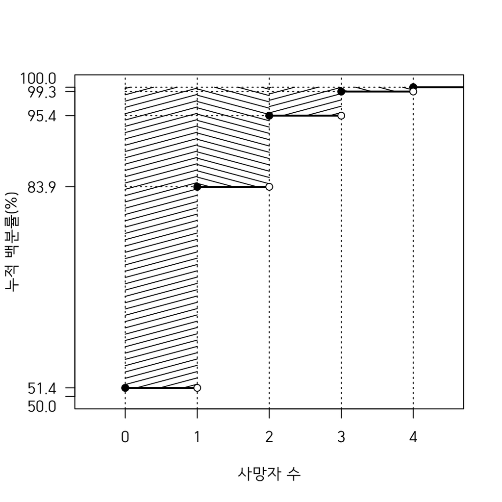

```r
points(x = n_deaths, y = horsekick_cum,
       pch = 21, bg = "black", col = "black")
points(x = n_deaths[2:5], y = horsekick_cum[1:4],
       pch = 21, bg = "white", col = "black")
```

누적분포 윗 면적이 곧 평균임을 나타내기 위해 막대를 다른 방향으로 집적. 우선 좌표들을 다시 정리하자.

```r
poly_x_2 <- matrix(c(rep(0, 4), rep(1:4, 2), rep(0, 4)),
                   ncol = 4, byrow = TRUE)
poly_y_2 <- rbind(sapply(horsekick_cum[1:4], rep, times = 2),
                  sapply(horsekick_cum[2:5], rep, times = 2))
poly_xy_2 <- rbind(poly_x_2, poly_y_2)
```

```r
par(family = "HCR Dotum LVT")
source("horsekick_plot.R")
apply(h_xy, MARGIN = 2, FUN = l_xy)
```

```r
mapply(polygon,
       lapply(data.frame(poly_xy_2), function(v) cbind(v[1:4], v[5:8])),
       density = 15, angle = c(15, 165, 15, 165), border = NA)
```

[figure not shown]

```r
points(x = n_deaths, y = horsekick_cum,
       pch = 21, bg = "black", col = "black")
points(x = n_deaths[2:5], y = horsekick_cum[1:4],
       pch = 21, bg = "white", col = "black")
```

중간에 약간의 작업이 들어가긴 하지만 아래 소스코드와 비교하라.

```r
options(digits = 3)
png(filename = "../pics/horsekick_prob.png", width = 480, height = 480)
par(family = "HCR Dotum LVT")
source("./horsekick_plot.R", echo = FALSE)
apply(h_xy, MARGIN = 1, FUN = l_xy)
```

```r
polygon(c(0, 1, 1, 0), c(rep(horsekick_cum[1], 2), rep(horsekick_cum[2], 2)),
        col = h_pal[1])
polygon(c(0, 2, 2, 0), c(rep(horsekick_cum[2], 2), rep(horsekick_cum[3], 2)),
        col = h_pal[2])
polygon(c(0, 3, 3, 0), c(rep(horsekick_cum[3], 2), rep(horsekick_cum[4], 2)),
        col = h_pal[3])
polygon(c(0, 4, 4, 0), c(rep(horsekick_cum[4], 2), rep(horsekick_cum[5], 2)),
        col = h_pal[4])
points(x = n_deaths, y = horsekick_cum,
       pch = 21, bg = "black", col = "black")
points(x = n_deaths[2:5], y = horsekick_cum[1:4],
       pch = 21, bg = "white", col = "black")
dev.off()
```

이번에 쌓아놓은 막대 면적의 합은 평균을 계산한 것임을 확인.